# DS3 Final Project EDA – Predicting Made and Missed Shots in the NBA

By Andrew Fenichel

**Initial Overview of Data**

Data set 1: https://data.world/rezabr/nba-shot-logs-2015

Data set 2: https://data.world/rvino88/1976-to-2015-nba-draft-data/workspace/file?filename=1976_to_2015_Draftees_edit2.csv

Data set 3: https://data.world/jgrosz99/nba-player-data-1978-2016/workspace/file?filename=NBA+Season+Data.csv

Observations (n): 105734

Number of features (p): 30

Missingness: Only two variables contain missing data in my master data set. `shot_clock` has 4826 missing data points out of 110814 observations, and `nba_3ptpct` has 263 missing observations out of 110814 observations. For some games, the shot clock data simply was not recorded, and I do not see this as a major limitation of the data, as my I do not expect to heavily use `shot_clock` as a predictor of my repsonse variable `fgm`. The missing data points for `nba_3ptpct` are conected to players who have never attempted a 3 point shot in their NBA career. Either way, I removed all missing observations for clarity.

**Essential Findings**

My response variable, `fgm`, is a binary variable coded as 1 = a made field goal and 0 = a missed field goal.

Using a correlation plot, I found that that very few of my variables are highly correlated with eachother–and furthermore, my repsonse variable has o strong correlations with any interesting predictor variables. WHile this is slightly suprising and somewhat dissapointing, it ibviously does not mean a succesful model cannot be produced for prediction. This will most likely mean that my models will require a high number of predictor variables in order to achieve a high rate of prediction on my test data.

```
##                final_margin shot_number period shot_clock dribbles touch_time
## final_margin           1.00        0.01   0.00      -0.01     0.01       0.01
## shot_number            0.01        1.00   0.66      -0.03     0.15       0.15
## period                 0.00        0.66   1.00      -0.05     0.06       0.05
## shot_clock            -0.01       -0.03  -0.05       1.00    -0.08      -0.15
## dribbles               0.01        0.15   0.06      -0.08     1.00       0.93
## touch_time             0.01        0.15   0.05      -0.15     0.93       1.00
## shot_dist              0.00        0.00   0.03      -0.18    -0.08      -0.08
## pts_type               0.03       -0.01   0.05      -0.03    -0.17      -0.18
## close_def_dist         0.03       -0.04  -0.01       0.02    -0.15      -0.17
## fgm                    0.06       -0.01  -0.01       0.10    -0.04      -0.05
## pts                    0.07       -0.01  -0.01       0.08    -0.06      -0.07
## weight                 0.01       -0.02  -0.06      -0.03    -0.34      -0.26
## nba_3ptpct             0.03        0.11   0.03      -0.01     0.16       0.13
## nba_efgpct             0.11       -0.03  -0.04       0.06    -0.15      -0.14
## nba_fg_percent         0.05       -0.01  -0.07       0.03    -0.19      -0.15
## nba_ppg                0.07        0.37  -0.03       0.00     0.20       0.23
## per                   -0.09        0.02  -0.04      -0.01    -0.01       0.00
## stl_percent           -0.01        0.00   0.01       0.00     0.03       0.01
## blk_percent           -0.02        0.00  -0.04      -0.02    -0.04      -0.02
## dws                   -0.16        0.02  -0.06      -0.01    -0.02      -0.01
## dws_48                -0.16        0.01  -0.03      -0.02    -0.03      -0.01
## dbpm                  -0.09        0.00  -0.05      -0.02    -0.04      -0.02
## defense               -0.02        0.00  -0.02      -0.02    -0.01      -0.01
##                shot_dist pts_type close_def_dist   fgm   pts weight nba_3ptpct
## final_margin        0.00     0.03           0.03  0.06  0.07   0.01       0.03
## shot_number         0.00    -0.01          -0.04 -0.01 -0.01  -0.02       0.11
## period              0.03     0.05          -0.01 -0.01 -0.01  -0.06       0.03
## shot_clock         -0.18    -0.03           0.02  0.10  0.08  -0.03      -0.01
## dribbles           -0.08    -0.17          -0.15 -0.04 -0.06  -0.34       0.16
## touch_time         -0.08    -0.18          -0.17 -0.05 -0.07  -0.26       0.13
## shot_dist           1.00     0.74           0.54 -0.18 -0.06  -0.24       0.32
## pts_type            0.74     1.00           0.41 -0.11  0.04  -0.24       0.28
## close_def_dist      0.54     0.41           1.00  0.00  0.06  -0.08       0.15
## fgm                -0.18    -0.11           0.00  1.00  0.97   0.05      -0.05
## pts                -0.06     0.04           0.06  0.97  1.00   0.01       0.00
## weight             -0.24    -0.24          -0.08  0.05  0.01   1.00      -0.51
## nba_3ptpct          0.32     0.28           0.15 -0.05  0.00  -0.51       1.00
## nba_efgpct         -0.09    -0.01          -0.02  0.06  0.06   0.23      -0.08
## nba_fg_percent     -0.33    -0.31          -0.13  0.09  0.03   0.58      -0.56
```

[output cut: 41 more lines]

```
## close_def_dist -0.03  -0.05 -0.05   -0.03
## fgm            -0.01  -0.02 -0.01   -0.01
## pts            -0.03  -0.03 -0.03   -0.02
## weight          0.12   0.19  0.23    0.09
## nba_3ptpct     -0.08  -0.15 -0.16   -0.09
## nba_efgpct      0.04   0.04  0.06    0.02
## nba_fg_percent  0.12   0.17  0.19    0.10
## nba_ppg         0.04   0.00  0.02    0.01
## per             0.59   0.40  0.28    0.38
## stl_percent     0.20   0.17  0.17    0.60
## blk_percent     0.40   0.59  0.70    0.66
## dws             1.00   0.76  0.68    0.49
## dws_48          0.76   1.00  0.82    0.62
## dbpm            0.68   0.82  1.00    0.71
## defense         0.49   0.62  0.71    1.00
```

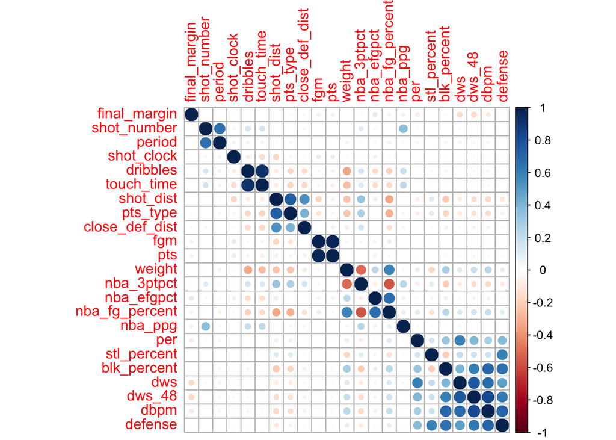

Of course, the one execption to the lack of correlation for my response variable was the predictor variable `pts`, which has a correlation of essentially 1. This makes logical sense.

Further exploring my predictor variables, through the use of box plots, I found that position and weight have a positive relationship, as do position and height (larger players, both in weight and height, tend to play “forward” or “center” versus “guard”).

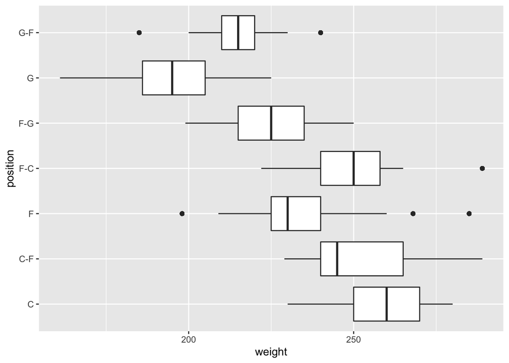

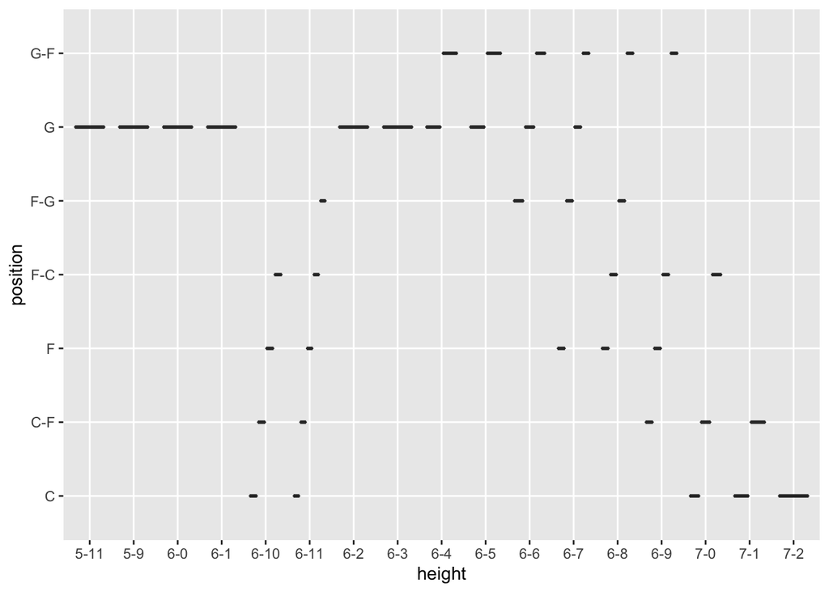

I also found that players who shoot a higher percentage from three shoot a comparitively lower percentage overall, which also makes sense because the three pointer is a lower-percentage shot because it is further away from the basket.

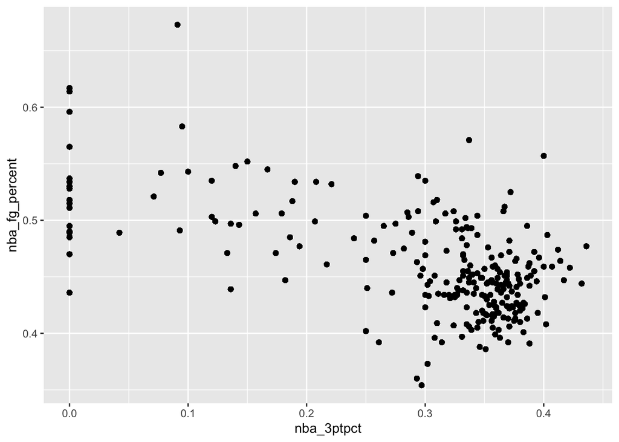

**Secondary Findings**

Further exploring my data, I found a couple other interesting, but expected, relationships. By constructing a bar graph of the frequency of shot distances, there is a big dip in field goals attempted in the “midrange”, or ~9-18 feet from the basket. This is expected, as the midrange jump shot is considered the least efficient shot in basketabll.

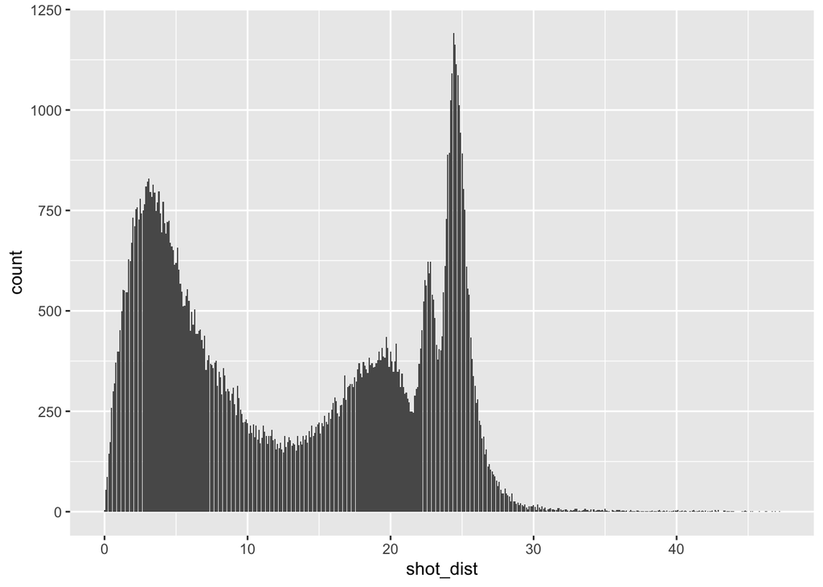

Additionally, I found that all of the advanced defensive metrics are relatively correlated with eachother, which is a good and expected discovery. These defensive metrics can be arbitrary and undeveloped, so the fact that the group I used all say that NBA players fall under similar levels of defensive ability means they are legitimate statistics.

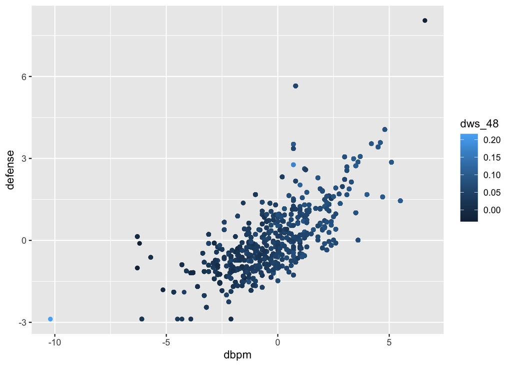

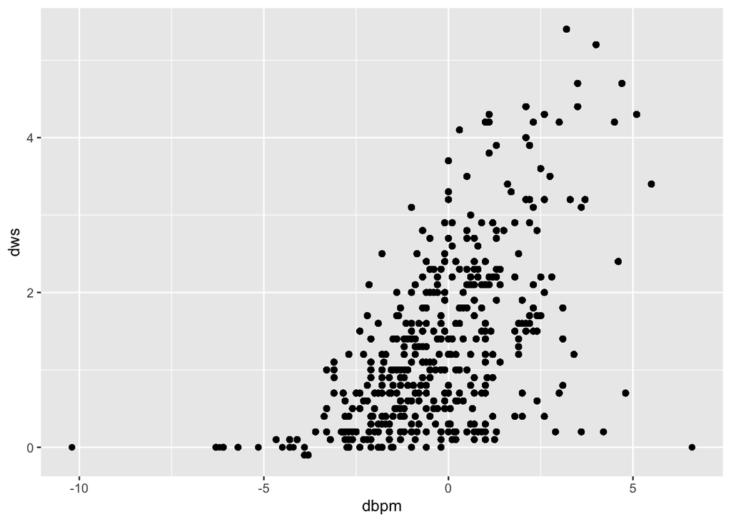

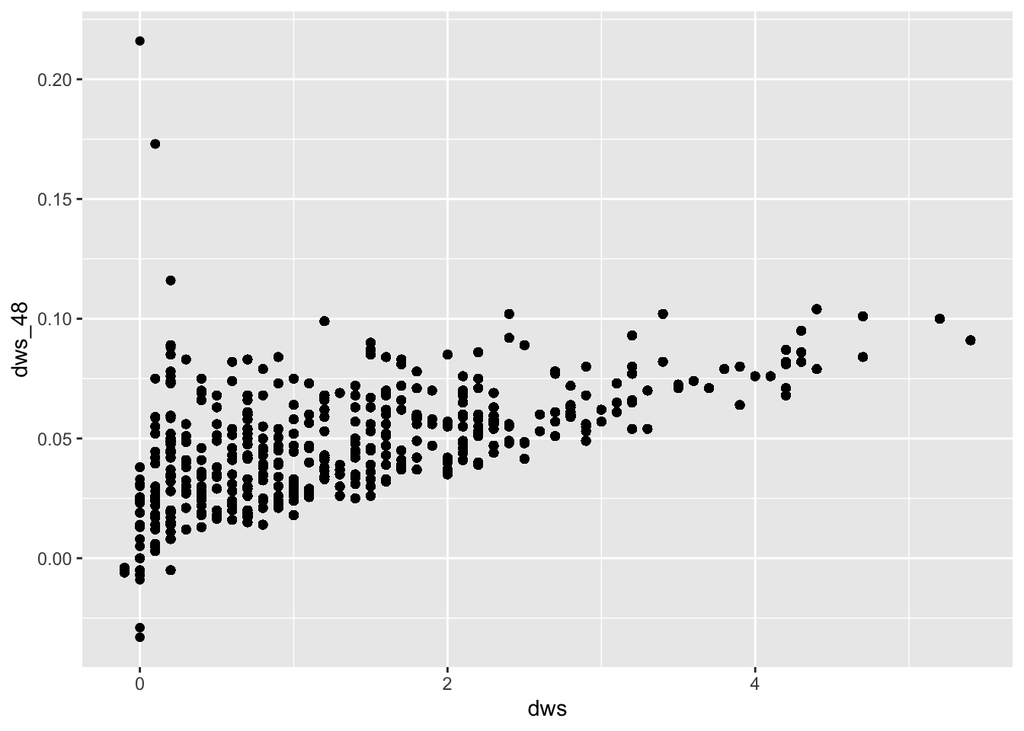